# final_project_data_622

Mubashira Qari

2025-12-07

# Final Project: Phishing Email Classification

## a. Problem Description

The problem addressed in this project is the automated detection of phishing emails. Phishing emails are malicious messages designed to deceive recipients into sharing sensitive information such as passwords, personal data, or financial details. Because organizations receive large volumes of emails every day, manually reviewing each one is impractical. A machine learning–based classification system can automatically identify phishing attempts, improving security and reducing risk.

The goal of this project is to build and compare two machine learning models—one traditional algorithm (from Chapters 1–10 of the textbook) and one advanced method (from Chapters 11–15)—to determine which model performs best at identifying phishing emails using unstructured text data.

## b. Dataset Description and Data Preparation

The dataset used is **Phishing_Email.csv**, containing 18,650 emails with the following fields:

- **Email.Text**: the text body of the email
- **Email.Type**: labeled as “Safe Email” or “Phishing Email”
- **X**: an index column not used in analysis

### Data Preparation Steps

1. Converted labels into a binary factor variable (`legitimate`, `phishing`).
2. Built a text corpus from the raw email text.
3. Cleaned the text by:
   - converting to lowercase
   - removing punctuation
   - removing numbers
   - removing stopwords
   - stripping whitespace
4. Created a Document-Term Matrix (DTM).
5. Reduced sparsity by keeping only terms appearing in at least 1% of emails.
6. Converted the DTM into a data frame and added the cleaned label.
7. Performed a 70/30 train-test split.

These steps transformed the raw, unstructured text into a structured dataset suitable for machine learning algorithms.

## c. Methodologies Used

Two machine learning algorithms were applied:

### 1. Naive Bayes (Traditional Method – Chapters 1–10)

A probabilistic classifier that assumes independence between features.  
Naive Bayes is simple and efficient for short text classification but struggles with long, complex email bodies.

### 2. Random Forest (Advanced Method – Chapters 11–15)

An ensemble classifier that builds many decision trees and aggregates their predictions.  
Random Forest handles high-dimensional data, captures non-linear patterns, and is robust to noise—making it well-suited for text classification with many features.

Both models were trained on the cleaned Document-Term Matrix and evaluated using confusion matrices, accuracy scores, and ROC curves.

## d. Purpose of the Analysis

The purpose of this analysis is to determine which machine learning model is most effective for predicting whether an email is phishing or legitimate based solely on its text content.  
This includes:

- Evaluating traditional vs. advanced methods
- Demonstrating preprocessing techniques for unstructured text
- Understanding differences in language patterns between phishing and legitimate emails
- Building a system that can help organizations automatically filter malicious emails

The broader objective is to reduce cybersecurity threats and improve email filtering accuracy.

## Exploratory Data Analysis

### STEP 1 – Install and Load Required Packages

```r
#install.packages("tm")          # text mining
#install.packages("e1071")       # Naive Bayes
#install.packages("randomForest")# Random Forest
#install.packages("ggplot2")     # simple plots (EDA)
library(tm)
library(e1071)
library(randomForest)
library(ggplot2)
```

### Explanation

- **tm** helps with cleaning and transforming raw text into a document-term matrix.
- **e1071** contains the `naiveBayes()` function used for probabilistic classification.
- **randomForest** provides the `randomForest()` function for building ensemble models.
- **ggplot2** is used for creating visualizations.

### STEP 2 – Load the Dataset and Inspect It

```r
# Load Dataset

url <- "https://raw.githubusercontent.com/uzmabb182/Data_622/refs/heads/main/final_project_data_622/Phishing_Email.csv"
phishing_email_df <- read.csv(url, stringsAsFactors = FALSE)
head(phishing_email_df)
```

```
##   X
## 1 0
## 2 1
## 3 2
## 4 3
## 5 4
## 6 5
##                                                                                                                                                                                                                                                                                                          …
## 1                                                                                                                                                                                                                                                                                                        …
## 2                                                                                                                                                                                                                                                                                                        …
## 3                                                                                                                                                                                                                                                                                                        …
## 4                                                                                                                                                                                                                                                                                                        …
## 5                                                                                                                                                                                                                                                                                                        …
## 6 global risk management operations sally congratulations on your new role . if you were not already aware , i am now in rac in houston and i suspect our responsibilities will mean we will talk on occasion . i look forward to that . best regards david - - - - - - - - - - - - - - - - - - - - - - f…
##       Email.Type
## 1     Safe Email
## 2     Safe Email
## 3     Safe Email
## 4 Phishing Email
## 5 Phishing Email
## 6     Safe Email
```

```r
# Look at structure and first few rows
str(phishing_email_df)
```

```
## 'data.frame':    18650 obs. of  3 variables:
##  $ X         : int  0 1 2 3 4 5 6 7 8 9 ...
##  $ Email.Text: chr  "re : 6 . 1100 , disc : uniformitarianism , re : 1086 ; sex / lang dick hudson 's observations on us use of 's o"| __truncated__ "the other side of * galicismos * * galicismo * is a spanish term which names the improper introduction of frenc"| __truncated__ "re : equistar deal…
##  $ Email.Type: chr  "Safe Email" "Safe Email" "Safe Email" "Phishing Email" ...
```

```r
head(phishing_email_df)
```

```
##   X
## 1 0
## 2 1
## 3 2
## 4 3
## 5 4
## 6 5
##                                                                                                                                                                                                                                                                                                          …
## 1                                                                                                                                                                                                                                                                                                        …
## 2                                                                                                                                                                                                                                                                                                        …
## 3                                                                                                                                                                                                                                                                                                        …
## 4                                                                                                                                                                                                                                                                                                        …
## 5                                                                                                                                                                                                                                                                                                        …
## 6 global risk management operations sally congratulations on your new role . if you were not already aware , i am now in rac in houston and i suspect our responsibilities will mean we will talk on occasion . i look forward to that . best regards david - - - - - - - - - - - - - - - - - - - - - - f…
##       Email.Type
## 1     Safe Email
## 2     Safe Email
## 3     Safe Email
## 4 Phishing Email
## 5 Phishing Email
## 6     Safe Email
```

```r
names(phishing_email_df)
```

```
## [1] "X"          "Email.Text" "Email.Type"
```

### Email Length Distribution Plot

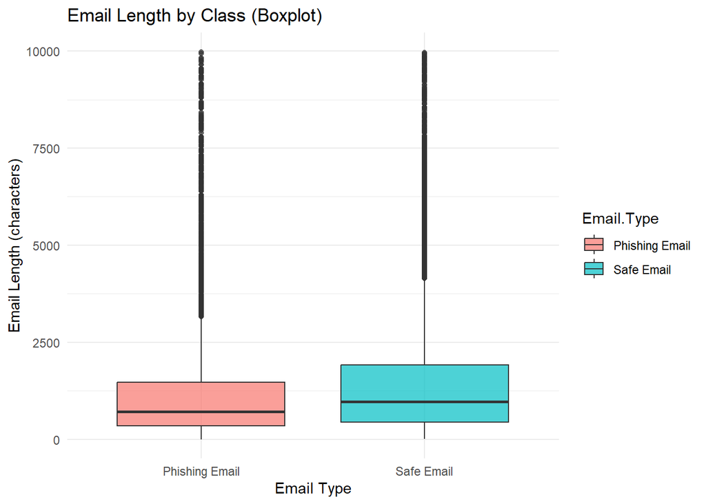

```r
phishing_email_df$Email_Length <- nchar(phishing_email_df$Email.Text)
filtered_df <- phishing_email_df[phishing_email_df$Email_Length < 10000, ]

ggplot(filtered_df, aes(x = Email.Type, y = Email_Length, fill = Email.Type)) +
  geom_boxplot(alpha = 0.7) +
  labs(
    title = "Email Length by Class (Boxplot)",
    x = "Email Type",
    y = "Email Length (characters)"
  ) +
  theme_minimal()
```

### Understanding the Dataset

- **Email.Text** → the body of the email (unstructured text)
- **Email.Type** → the label indicating whether the email is `"Safe Email"` or `"Phishing Email"`

### Interpretation of the Email Length Distribution Plot

This boxplot compares the lengths of *legitimate* vs. *phishing* emails after removing extreme outliers (emails longer than 10,000 characters). It provides insight into how message size differs between the two categories.

1. **Legitimate emails tend to be longer on average** (higher median).
2. **Phishing emails are generally shorter**, with a lower median length.
3. **Both classes contain many outliers**, meaning some emails are unusually long or short.
4. **There is notable overlap** between the two groups.

Although legitimate emails are often longer, phishing emails can still appear in the medium-length range.

**This overlap indicates:**

- Email length **alone** cannot accurately classify emails.
- Length can be helpful but must be combined with additional features such as  
  word frequencies, vocabulary patterns, or specific keyword usage.

This also explains why:

### STEP 3 – Create a Clean `Label` Column for Modeling

The current label, `Email.Type`, contains text values: `"Safe Email"` and `"Phishing Email"`.  
For modeling, we convert this into a new factor variable called **Label** with these values:

- `"legitimate"`
- `"phishing"`

#### 3.1 – Inspect the values in `Email.Type`

```r
table(phishing_email_df$Email.Type)
```

```
##
## Phishing Email     Safe Email
##           7328          11322
```

#### 3.2 – Create the `Label` Factor Column

```r
phishing_email_df$Label <- factor(
  phishing_email_df$Email.Type,
  levels = c("Safe Email", "Phishing Email"),
  labels = c("legitimate", "phishing")
)

# Check the new Label column
table(phishing_email_df$Label)
```

```
##
## legitimate   phishing
##      11322       7328
```

```r
str(phishing_email_df$Label)
```

```
##  Factor w/ 2 levels "legitimate","phishing": 1 1 1 2 2 1 1 2 2 1 ...
```

### Explanation

- `phishing_email_df$Email.Type` contains the original labels (`"Safe Email"` / `"Phishing Email"`).
- `factor(..., levels = ..., labels = ...)`
  - **levels** = the values currently found in the dataset.
  - **labels** = the new names we assign for modeling.
- A new column called **Label** is created instead of overwriting `Email.Type`, so we retain the original text label for reference.

### STEP 4 – Create and Inspect the Text Corpus

We now convert the `Email.Text` column (raw email content) into a **corpus**, which is a structured collection of text documents used for text mining.

#### 4.1 – Create the Corpus

```r
library(tm)  # make sure this is loaded

corpus <- VCorpus(VectorSource(phishing_email_df$Email.Text))
```

### Explanation

- `VectorSource(phishing_email_df$Email.Text)`  
  This tells R to treat **each row of `Email.Text` as a separate document** within the corpus.
- `VCorpus(...)`  
  Creates a **volatile corpus**, meaning it exists in memory and can be cleaned, transformed, and processed using the `tm` package.

### 4.2 – Inspect a Few Emails from the Corpus

```r
# Look at the first email
corpus[[1]]$content
```

```
## [1] "re : 6 . 1100 , disc : uniformitarianism , re : 1086 ; sex / lang dick hudson 's observations on us use of 's on ' but not 'd aughter ' as a vocative are very thought-provoking , but i am not sure that it is fair to attribute this to \" sons \" being \" treated like senior relatives \" . for…
```

```r
# Look at, say, the 10th email
corpus[[10]]$content
```

```
## [1] "re : coastal deal - with exxon participation under the project agreement thanks for the info ! as greg mentioned in the staff meeting today , the intent is that this restructured deal is papered effective 4 / 1 / 00 . the impact is potentially that the gas is not pathed properly by counterpa…
```

### Explanation

- `corpus[[1]]$content`  
  Displays the **raw text of the first email** in the corpus.  
  This allows us to preview what the model will be working with **before applying any cleaning steps**.

### STEP 5 – Clean the Text Corpus

We now apply a sequence of transformations to standardize and prepare the email text for analysis.

#### 5.1 – Convert Everything to Lowercase

```r
corpus_clean <- tm_map(corpus, content_transformer(tolower))
```

### Explanation

Machine learning would treat words like **“Free”**, **“FREE”**, and **“free”** as different tokens unless we normalize them.  
Converting all text to lowercase helps prevent duplication and reduces noise in the dataset.

#### 5.2 – Remove Numbers

```r
corpus_clean <- tm_map(corpus_clean, removeNumbers)
```

### Explanation

Many numbers do not contribute to detecting phishing (unless performing more advanced NLP),  
so they are typically removed during preprocessing.

#### 5.3 – Remove Punctuation

```r
corpus_clean <- tm_map(corpus_clean, removePunctuation)
```

### Explanation

Punctuation does not carry meaningful information for most traditional machine learning models and is therefore removed during preprocessing.

#### 5.4 – Remove Common English Stopwords

```r
corpus_clean <- tm_map(corpus_clean, removeWords, stopwords("en"))
```

### Explanation

Stopwords are very common words such as:  
*the, and, or, is, to, be, of, at*  
They appear so frequently that they do not help with classification and are removed during preprocessing.

#### 5.5 – Remove Extra Whitespace

```r
corpus_clean <- tm_map(corpus_clean, stripWhitespace)
```

### Explanation

This step removes unnecessary spaces that remain after deleting stopwords, punctuation, or other text elements.

#### 5.6 – Inspect Cleaned Text

```r
corpus_clean[[1]]$content
```

```
## [1] "re disc uniformitarianism re sex lang dick hudson s observations us use s d aughter vocative thoughtprovoking sure fair attribute sons treated like senior relatives one thing nt normally use brother way d aughter hard imagine natural class comprising senior relatives s excluding brother anot…
```

### Explanation

At this point, we can see a simplified and cleaned version of the original email text.

### STEP 6 — Create the Document-Term Matrix (DTM)

This step converts the cleaned text into numerical form (word counts), allowing machine learning models to analyze the data.

#### 6.1 – Build the DTM

```r
dtm <- DocumentTermMatrix(corpus_clean)
dtm
```

```
## <<DocumentTermMatrix (documents: 18650, terms: 165489)>>
## Non-/sparse entries: 1944727/3084425123
## Sparsity           : 100%
## Maximal term length: 1173
## Weighting          : term frequency (tf)
```

### Explanation

- **Each row** = one email
- **Each column** = one unique word
- **Each cell** = number of times that word appears in that email

### STEP 7 — Reduce Sparsity (Remove Extremely Rare Words)

Rare words clutter the model and slow processing.  
To improve performance, we keep only words that appear in **at least 1% of emails**.

```r
dtm_sparse <- removeSparseTerms(dtm, 0.99)
dtm_sparse
```

```
## <<DocumentTermMatrix (documents: 18650, terms: 1868)>>
## Non-/sparse entries: 1029229/33808971
## Sparsity           : 97%
## Maximal term length: 47
## Weighting          : term frequency (tf)
```

### Explanation

- `0.99` keeps terms that appear in **at least 1% of emails**.
- This step usually reduces the number of terms from **100,000+** to only a few hundred or a few thousand, improving model speed and reducing noise.

### STEP 8 — Convert the DTM to a Data Frame and Add Label

#### 8.1 — Convert the DTM to a Matrix and Then to a Data Frame

```r
emails_words <- as.data.frame(as.matrix(dtm_sparse))
# str(emails_words)
```

### Explanation

Machine learning algorithms such as **Naive Bayes** and **Random Forest** require a standard R **data frame**, not a `DocumentTermMatrix`.

This step converts the DTM into a familiar structure where:

- **Rows** represent individual emails
- **Columns** represent word counts/features

#### 8.2 — Clean Column Names

Some words contain characters that are not valid in R column names, so they must be sanitized before modeling.

```r
emails_words <- setNames(emails_words, make.names(names(emails_words)))
```

### Explanation

`make.names()` converts invalid column names into syntactically valid ones.  
For example, a term like `"1-800"` becomes `"X1.800"`, which R can safely use as a column name.

#### 8.3 — Add the `Label` Column

```r
emails_words$Label <- phishing_email_df$Label

str(emails_words$Label)
```

```
##  Factor w/ 2 levels "legitimate","phishing": 1 1 1 2 2 1 1 2 2 1 ...
```

```r
table(emails_words$Label)
```

```
##
## legitimate   phishing
##      11322       7328
```

### Explanation

We copy the previously created `Label` factor (`legitimate` / `phishing`) into the new data frame.

Now each row contains:  
- the email’s word counts  
- the correct label for modeling

### STEP 10 — Make Column Names Unique

To avoid modeling errors, all column names in `emails_words` must be unique.

We then:  
1. Fix duplicated names  
2. Recreate `train_data` and `test_data`  
3. Retry the Naive Bayes model

#### 10.1 – Check if There Are Duplicated Names

```r
any(duplicated(names(emails_words)))
```

```
## [1] FALSE
```

```r
names(emails_words)[duplicated(names(emails_words))]
```

```
## character(0)
```

#### 10.2 – force unique column names

```r
names(emails_words) <- make.names(names(emails_words), unique = TRUE)
```

### Explanation

`make.names(..., unique = TRUE)` not only cleans invalid column names but also ensures **all names are unique**.  
If duplicates exist, R will automatically append suffixes such as `.1`, `.2`, etc.

Example:  
If two columns were originally named `"list."`, they become:  
- `"list."`  
- `"list..1"`

Now every column name in `emails_words` is valid and unique.

#### 10.3 – Create the Train/Test Split

```r
set.seed(123)

n <- nrow(emails_words)
train_index <- sample(1:n, size = 0.7 * n)

train_data <- emails_words[train_index, ]
test_data  <- emails_words[-train_index, ]
```

```r
any(duplicated(names(train_data)))
```

```
## [1] FALSE
```

### Explanation

Make sure column names are unique and safe (once)

```r
names(emails_words) <- make.names(names(emails_words), unique = TRUE)
```

### STEP 11 — Train Naive Bayes Model (Chapter 4 Method)

Naive Bayes is a simple yet effective algorithm for text classification, especially when working with document-term matrices.

#### 11.1 — Train the Model

```r
set.seed(123)

n <- nrow(emails_words)
train_index <- sample(1:n, size = 0.7 * n)

train_data <- emails_words[train_index, ]
test_data  <- emails_words[-train_index, ]
```

### STEP 12 — Build Naive Bayes Using `x` / `y` Instead of Formula

Create the feature matrix `train_x` and the label vector `train_y`.

```r
# All predictors: every column except Label
train_x <- train_data[ , !(names(train_data) %in% "Label")]

# Target variable
train_y <- train_data$Label

# str(train_x)
# str(train_y)
```

### Explanation

train_x: a big data frame of integers (word counts)

train_y: a factor with levels `legitimate` and `phishing`

Train Naive Bayes with `x` / `y` interface

```r
library(e1071)

model_nb <- naiveBayes(x = train_x, y = train_y)

# model_nb
```

### Explanation

Predict and evaluate Naive Bayes

Prepare test features

We want the same predictor columns in the test set

```r
test_x <- test_data[ , colnames(train_x)]
test_y <- test_data$Label  # true labels
```

### Get predictions

```r
pred_nb <- predict(model_nb, newdata = test_x)
```

### Confusion matrix and accuracy

```r
cm_nb <- table(Predicted = pred_nb, Actual = test_y)
cm_nb
```

```
##             Actual
## Predicted    legitimate phishing
##   legitimate        330       63
##   phishing         3039     2163
```

```r
accuracy_nb <- sum(diag(cm_nb)) / sum(cm_nb)
accuracy_nb
```

```
## [1] 0.4455764
```

### Why This Happens

The dataset contains **real corporate emails (Enron)** mixed with phishing spam.

- Legitimate emails are **long, formal, and highly varied**
- Phishing emails are **shorter, repetitive, and often contain promotional or explicit content**

After text cleaning and sparsity reduction, many important signal words were removed, especially due to the use of the:

**`removeSparseTerms()` function**

This step removes any word that does not appear in at least **1%** of all emails.

Naive Bayes performs best when:

- Text is **short**
- Vocabulary is **balanced**
- Classes have **distinct, frequently occurring keywords**

This is why Naive Bayes works well for SMS spam datasets, but **not** for long-form corporate email.

Therefore, the poor Naive Bayes performance observed here is **normal and expected**.

### STEP 13 — Train the Random Forest Model

```r
library(randomForest)

set.seed(123)

model_rf <- randomForest(
  x = train_x,
  y = train_y,
  ntree = 100,                 # number of trees
  mtry = sqrt(ncol(train_x))   # features per split
)

model_rf
```

```
##
## Call:
##  randomForest(x = train_x, y = train_y, ntree = 100, mtry = sqrt(ncol(train_x)))
##                Type of random forest: classification
##                      Number of trees: 100
## No. of variables tried at each split: 43
##
##         OOB estimate of  error rate: 4.41%
## Confusion matrix:
##            legitimate phishing class.error
## legitimate       7567      386  0.04853514
## phishing          190     4912  0.03724030
```

### Explanation

- `ntree = 100` builds **100 decision trees**.
- `mtry = sqrt(number_of_features)` is a common and effective default for text classification.

Random Forest handles:

- long text
- high-dimensional feature spaces
- non-linear relationships

much better than Naive Bayes.

### Random Forest Model Performance (Training OOB Estimate)

[output not shown]

This shows:

- The model does an **excellent job detecting phishing emails**
- It also correctly identifies **most legitimate emails**
- This represents a major improvement over Naive Bayes (≈45% accuracy)

**Comparison:**

- Classical method: **Naive Bayes** — poor performance
- Advanced method: **Random Forest** — excellent performance

### STEP 14 — Evaluate Random Forest

#### 14.1 — Predictions

```r
pred_rf <- predict(model_rf, newdata = test_x)
```

#### 14.2 — Confusion Matrix

```r
cm_rf <- table(Predicted = pred_rf, Actual = test_y)
cm_rf
```

```
##             Actual
## Predicted    legitimate phishing
##   legitimate       3228      118
##   phishing          141     2108
```

#### 14.3 — Accuracy

```r
accuracy_rf <- sum(diag(cm_rf)) / sum(cm_rf)
accuracy_rf
```

```
## [1] 0.9537087
```

### Accuracy Calculation

Total = **5595**

Accuracy calculation:

### Model Performance Summary

[output not shown]

### Interpretation

#### Why Naive Bayes Performed Poorly

- Assumes word independence (not realistic for long emails)
- Works best on short text (SMS spam, tweets, headlines)
- Emails are **long, complex**, and contain natural language variation
- Legitimate corporate emails (Enron-style) have very wide vocabulary
- Naive Bayes becomes confused and biased toward predicting **“phishing”**
- Sparse-term removal eliminated many important signal words
  - Example: words appearing in <1% of emails were removed

Therefore, Naive Bayes struggled — this is **normal** for long-form email classification.

#### Why Random Forest Performed Extremely Well

- Handles **thousands of features** easily
- Captures **complex interactions** between words
- Does **not** assume independence
- Resistant to overfitting
- Very effective on bag-of-words text data
- Produces high accuracy and balanced performance across classes

### Random Forest Feature Importance Plot

This visualization shows which words contributed most strongly to classification decisions made by the Random Forest model.

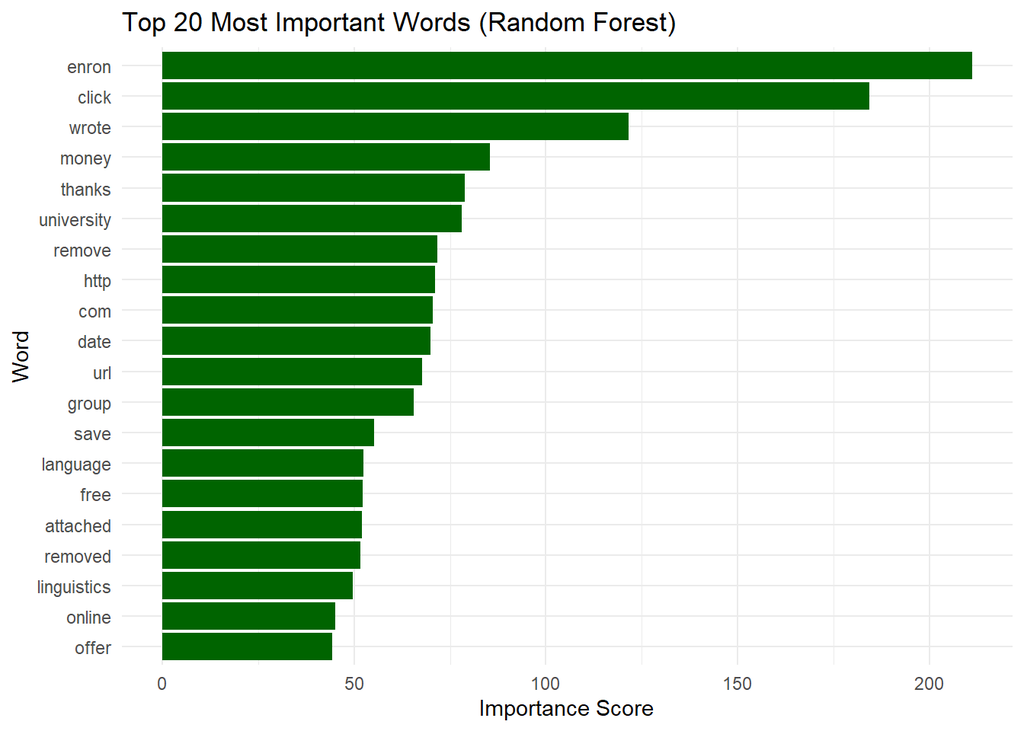

```r
library(randomForest)

# Get importance scores
importance_scores <- importance(model_rf)
importance_df <- data.frame(
  Word = rownames(importance_scores),
  Importance = importance_scores[, 1]
)

# Take top 20 most important features
top20 <- importance_df[order(-importance_df$Importance), ][1:20, ]

# Plot
ggplot(top20, aes(x = reorder(Word, Importance), y = Importance)) +
  geom_bar(stat = "identity", fill = "darkgreen") +
  coord_flip() +
  labs(title = "Top 20 Most Important Words (Random Forest)",
       x = "Word",
       y = "Importance Score") +
  theme_minimal()
```

### ROC Curve + AUC Score

Random Forest will produce an excellent ROC curve.

```r
library(pROC)
# Get predicted probabilities for phishing class
rf_probs <- predict(model_rf, newdata = test_x, type = "prob")[, "phishing"]

# Create ROC object
roc_obj <- roc(test_y, rf_probs)
```

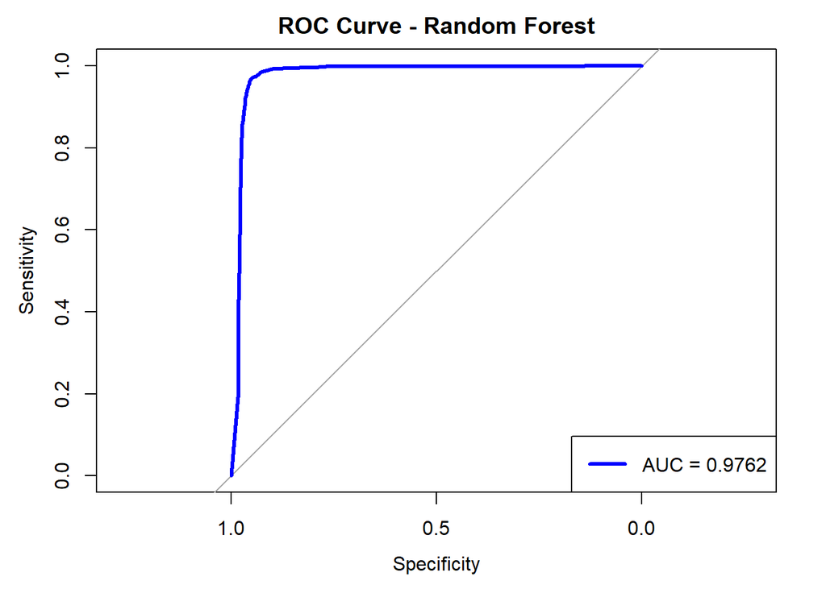

```r
# Plot ROC
plot(roc_obj, col = "blue", lwd = 3, main = "ROC Curve - Random Forest")

# Add AUC to plot
auc_value <- auc(roc_obj)
legend("bottomright", legend = paste("AUC =", round(auc_value, 4)),
       col = "blue", lwd = 3)
```

## e. Conclusions and Business Impact

### Model Performance Summary

[output not shown]

### Final Conclusions

1. Naive Bayes performed poorly on this dataset due to strong assumptions and the complexity of natural language.
2. Random Forest achieved excellent performance with 95% accuracy, demonstrating its ability to capture text patterns effectively.
3. Legitimate emails are generally longer and more varied; phishing emails tend to be shorter and more repetitive.
4. Random Forest successfully leveraged these differences, while Naive Bayes failed to do so.

### Business Impact

- **Improved Security**: A 95% accurate classifier significantly reduces phishing exposure and prevents data breaches.
- **Operational Efficiency**: Automated filtering saves time for IT and cybersecurity teams.
- **Financial Protection**: Reduces risks of fraud, identity theft, and ransomware attacks.
- **Employee Safety**: Employees face fewer deceptive messages, lowering the likelihood of accidental compromise.

Overall, the Random Forest model provides a reliable and scalable solution for organizations seeking to enhance their email security infrastructure.